# COMPSCIX 415.2 Homework 6

Inessa Wu

March 7, 2018

```r
library (tidyverse)
library (rmarkdown)
library (mosaicData)
library (lubridate)
```

### Exercise 1

```r
data(Whickham)
```

#### Question 1

Variables included in the data set are Outcome (Alive, Dead), Smoker (No, Yes), Age (age in years).

#### Question 2

There are 1,314 observations in this data set. Each observation represents a woman who took a survey.

#### Question 3

The summary table shows that higher share of non-smokers are dead 20 years after the initial survey has been taken. This outcome does not make sense. Age has to be a factor. It’s possible that larger share of non-smokers were older than that of smokers.

```r
Whickham %>% count(smoker, outcome)
```

```
## # A tibble: 4 x 3
##   smoker outcome     n
##   <fct>  <fct>   <int>
## 1 No     Alive     502
## 2 No     Dead      230
## 3 Yes    Alive     443
## 4 Yes    Dead      139
```

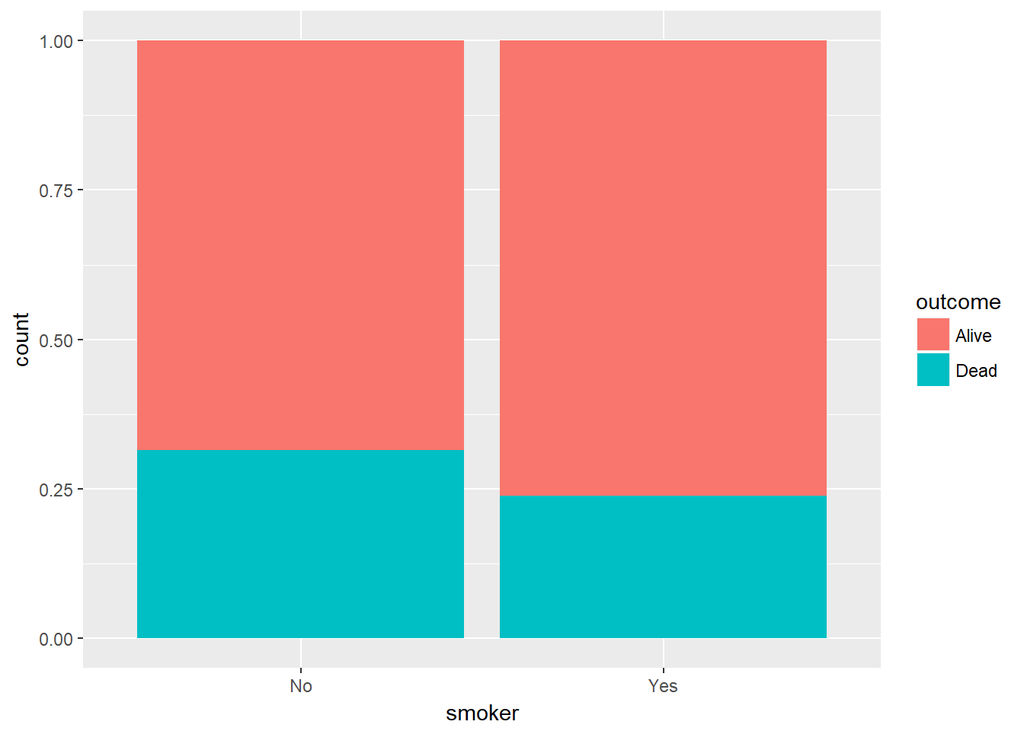

```r
ggplot(data=Whickham)+
  geom_bar(mapping=aes(x=smoker, fill=outcome), position="fill")
```

#### Question 4

Creating a new variable age_ctg to categorize survey responders into age groups. Checking that this step has been completed correctly.

```r
whicham_wkng <- Whickham %>% mutate (age_ctg = case_when(age <= 44 ~ 'age <= 44', age > 44 & age <=64 ~ 'age > 44 & age <= 64', age > 64 ~ 'age > 64'))

glimpse(whicham_wkng)
```

```
## Observations: 1,314
## Variables: 4
## $ outcome <fct> Alive, Alive, Dead, Alive, Alive, Alive, Alive, Dead, ...
## $ smoker  <fct> Yes, Yes, Yes, No, No, Yes, Yes, No, No, No, No, Yes, ...
## $ age     <int> 23, 18, 71, 67, 64, 38, 45, 76, 28, 27, 28, 34, 20, 72...
## $ age_ctg <chr> "age <= 44", "age <= 44", "age > 64", "age > 64", "age...
```

Converting age_ctg into orgered factor and assigning values to age_fct variable and creating a visualization. Checking that this step has been completed correctly.

```r
whicham_wkng <- whicham_wkng %>% mutate (age_fct = factor(age_ctg, ordered=TRUE))

glimpse(whicham_wkng)
```

```
## Observations: 1,314
## Variables: 5
## $ outcome <fct> Alive, Alive, Dead, Alive, Alive, Alive, Alive, Dead, ...
## $ smoker  <fct> Yes, Yes, Yes, No, No, Yes, Yes, No, No, No, No, Yes, ...
## $ age     <int> 23, 18, 71, 67, 64, 38, 45, 76, 28, 27, 28, 34, 20, 72...
## $ age_ctg <chr> "age <= 44", "age <= 44", "age > 64", "age > 64", "age...
## $ age_fct <ord> age <= 44, age <= 44, age > 64, age > 64, age > 44 & a...
```

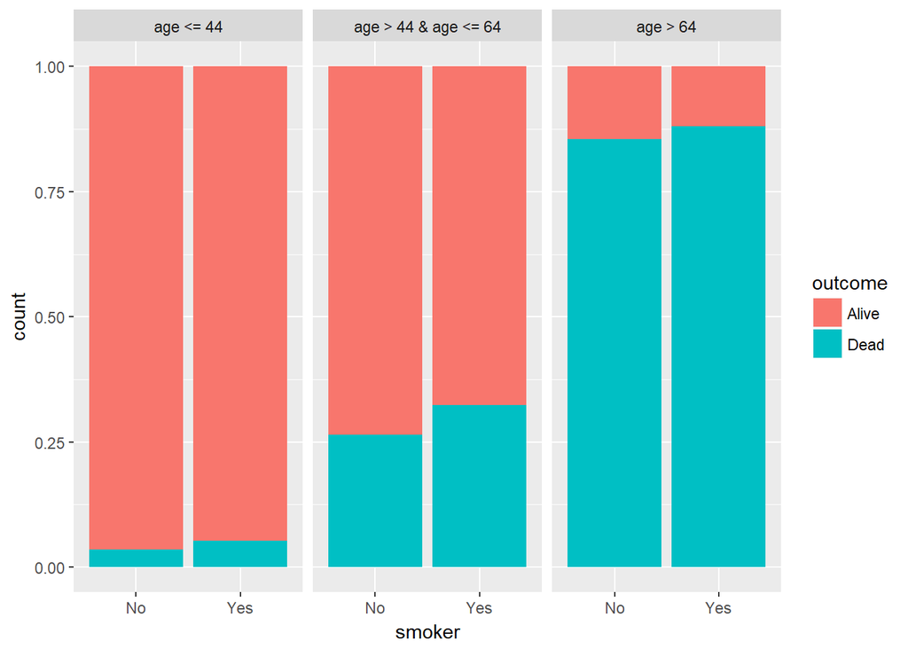

```r
ggplot(data = whicham_wkng)+
  geom_bar(mapping=aes(x=smoker, fill=outcome), position='fill')+
  facet_grid(~age_fct)
```

Visualiziation above makes more sense. By exposing age category, now the visualization shows that a larger share of non-smokers remained alive 20 years after the survey for each age category. It also shows that share of women dead increased with age for both smokers and non-smokers.

### Exercise 2

#### Question 1

Generating a random sample of size n = 10000 from a gamma(1,2) distribution and plotting a histogram or density curve

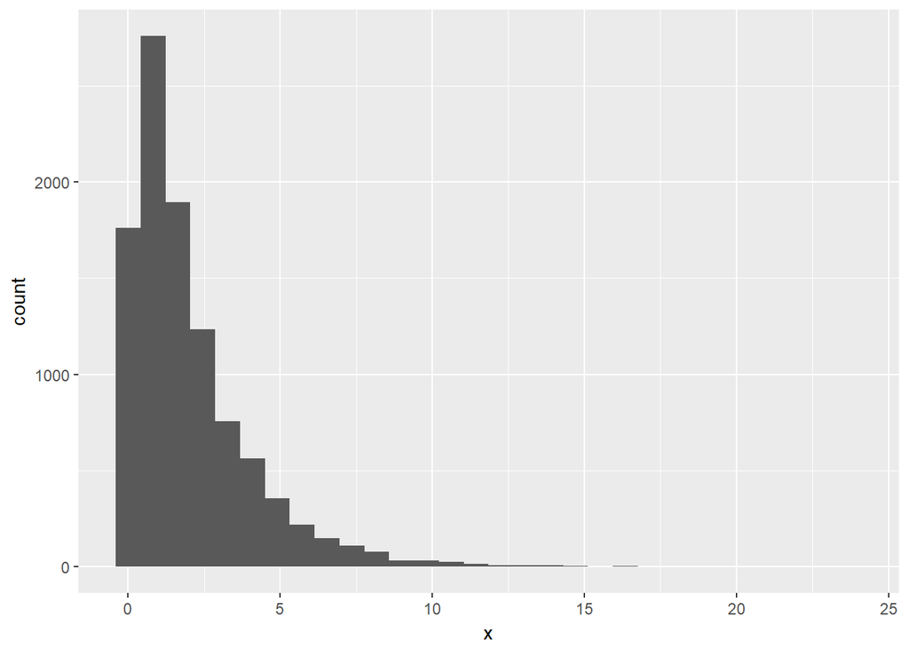

```r
n <- 10000

gamma_samp <- tibble(x = rgamma(n, shape = 1, scale = 2))

ggplot(gamma_samp)+
  geom_histogram(mapping=aes(x=x))
```

#### Question 2

```r
gamma_samp %>% summarize(mean_x = mean(x, na.rm = TRUE),
                      sd_x = sd(x, na.rm = TRUE)) %>%
  gather(key = stats, value = values)
```

```
## # A tibble: 2 x 2
##   stats  values
##   <chr>   <dbl>
## 1 mean_x   2.00
## 2 sd_x     2.00
```

#### Question 3

Taking a sample of size n = 30 from a Gamma(1,2) distribution and then plotting the histogram. Mean and standard deviation of the generated sample are shown below:

```r
gamma_n30 <- gamma_samp %>% sample_n(30)

gamma_n30 %>%
  summarize(mean_x = mean(x, na.rm = TRUE),
                      sd_x = sd(x, na.rm = TRUE)) %>%
  gather(key = stats, value = values)
```

```
## # A tibble: 2 x 2
##   stats  values
##   <chr>   <dbl>
## 1 mean_x   1.57
## 2 sd_x     1.67
```

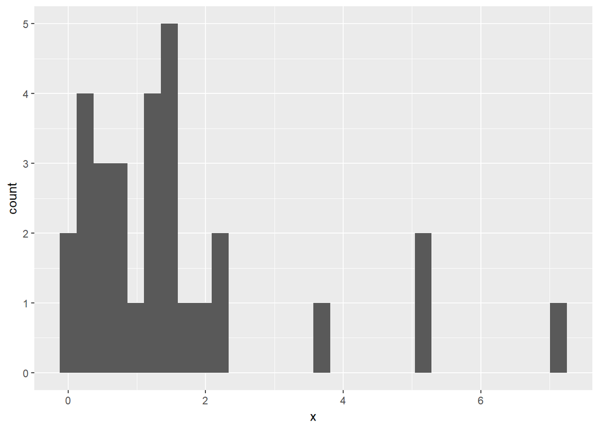

```r
ggplot(gamma_n30)+
  geom_histogram(mapping=aes(x=x))
```

#### Question 4

```r
# create a vector with 10000 NAs

mean_samp <- rep(NA, 10000)

# start a loop
for(i in 1:10000) {
  g_samp <- rgamma(30, shape = 1, scale = 2)
  mean_samp[i] <- mean(g_samp)
}
# Convert vector to a tibble
mean_samp <- tibble(mean_samp)
```

##### Question 5

Below is a histogram of the generated collection of means from (mean_samp)

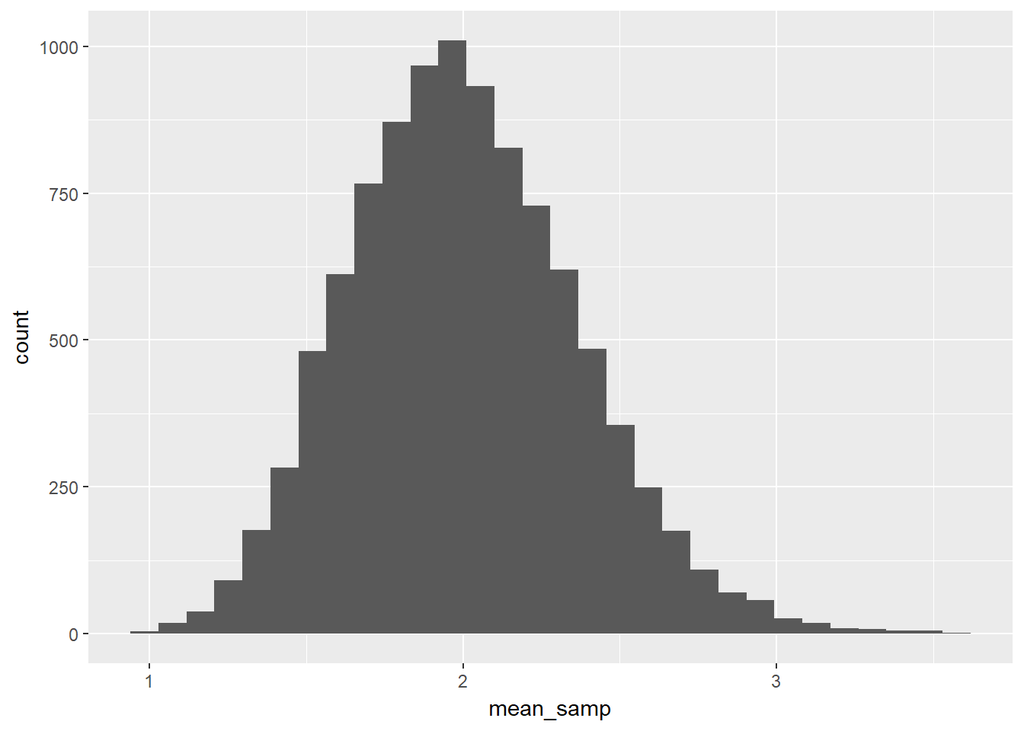

```r
ggplot(mean_samp)+
  geom_histogram(mapping=aes(x=mean_samp))
```

#### Question 6

Calculate the mean and standard deviation of all sample means.

```r
mean_samp %>%
  summarize(mean_smpl = mean(mean_samp, na.rm = TRUE),
                      sd_smpl = sd(mean_samp, na.rm = TRUE)) %>%
  gather(key = stats, value = values)
```

```
## # A tibble: 2 x 2
##   stats     values
##   <chr>      <dbl>
## 1 mean_smpl  2.00
## 2 sd_smpl    0.364
```

#### Question 7

None of he values are surprising. Both values are in line with the expectations based on Central Limit Theorem. Mean is close to 2, as expectged and standard deviation is close to 0.365.

#### Question 8

```r
# create a vector with 300 NAs

mean_samp300 <- rep(NA, 300)

# start a loop
for(i in 1:300) {
  g_samp300 <- rgamma(30, shape = 1, scale = 2)
  mean_samp300[i] <- mean(g_samp300)
}
# Convert vector to a tibble
mean_samp300 <- tibble(mean_samp300)
```

```r
mean_samp300 %>%
  summarize(mean_smpl300 = mean(mean_samp300, na.rm = TRUE),
                      sd_smpl300 = sd(mean_samp300, na.rm = TRUE)) %>%
  gather(key = stats, value = values)
```

```
## # A tibble: 2 x 2
##   stats        values
##   <chr>         <dbl>
## 1 mean_smpl300  2.00
## 2 sd_smpl300    0.386
```